# Cranberry Models: Common Control

## 1) Introduction

Crop production and harvest is an area of study whose output affects every general population. This is becuase everyone, regardless of their different facets of life - need to consume food to survive. With the growing trend of global temperature, food production and harvest quantity may fluctuate.

This study aims answer question about the effects of heat treatment to cranberries and result we observe in production of cranberries.

We aim of answer the following questions :

1. How does heat stress affect yield as measured by the total weight of fruit?
2. How does heat stress affect yield as measured by the total weight of healthy fruit?
3. How does heat stress affect yield as measured by the percentage of healthy berries by count?
4. How does heat stress affect yield as measured by the percentage of healthy fruit by weight?
5. How do the cultivars, years, and intensity of the heat shocks (in the case of the acute heat stress experiment) affect the various measures of yield?

## 2) Exploratory Data Analysis and Modifications

Let us visualize the data first

TODO : may be a proportional plot than healthy weight for ST and MQ

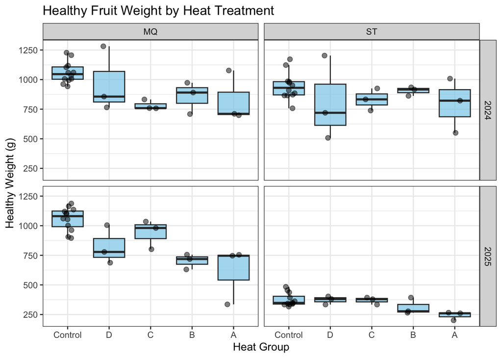

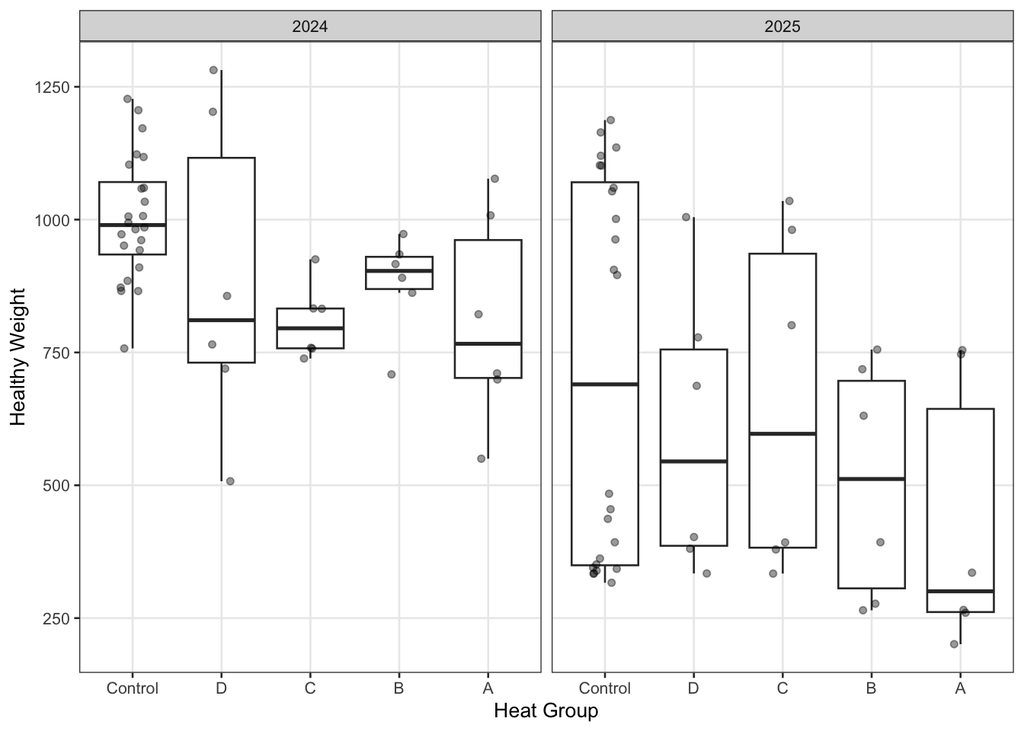

Healthy Fruit Proportion by Heat Treatment

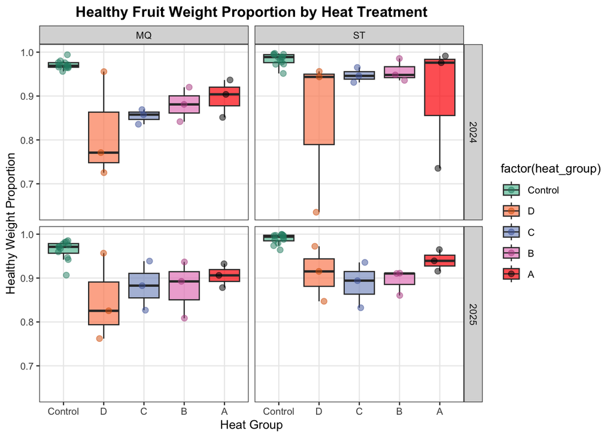

With the said data visualizations, we can observe how correlated the characteristics of the study are.

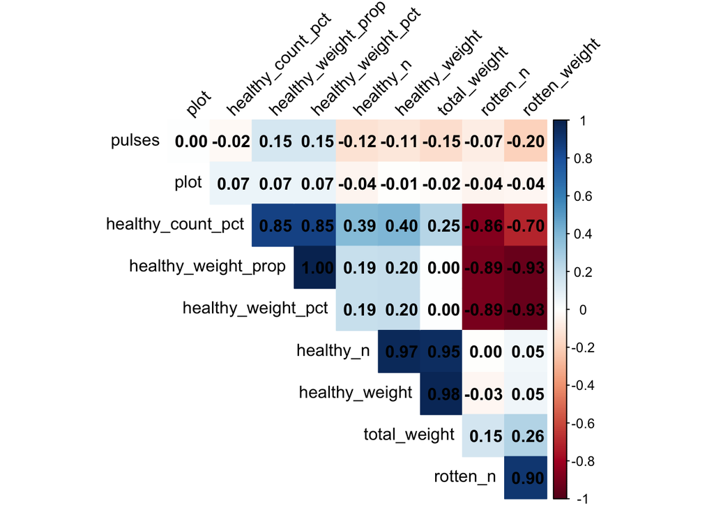

Testing the density distribution of Total Weight

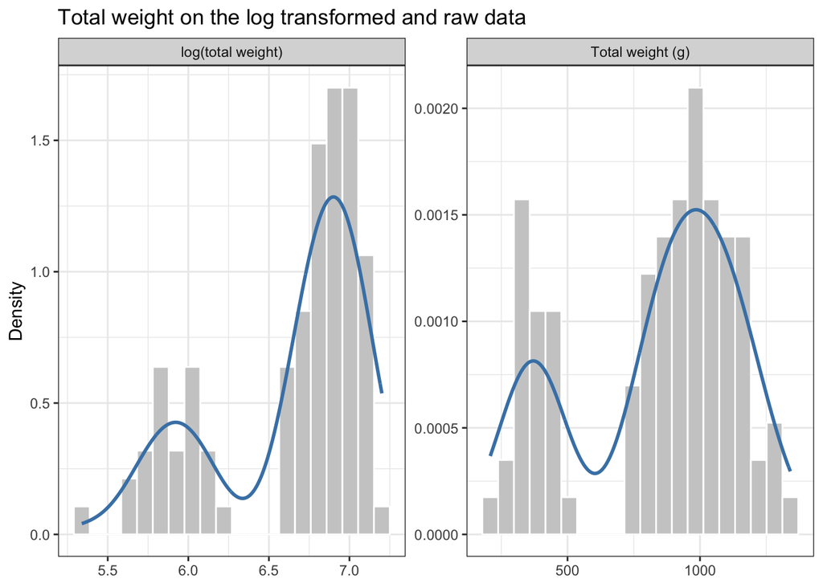

Log transformations fix right-skewness—they cannot fix bimodality

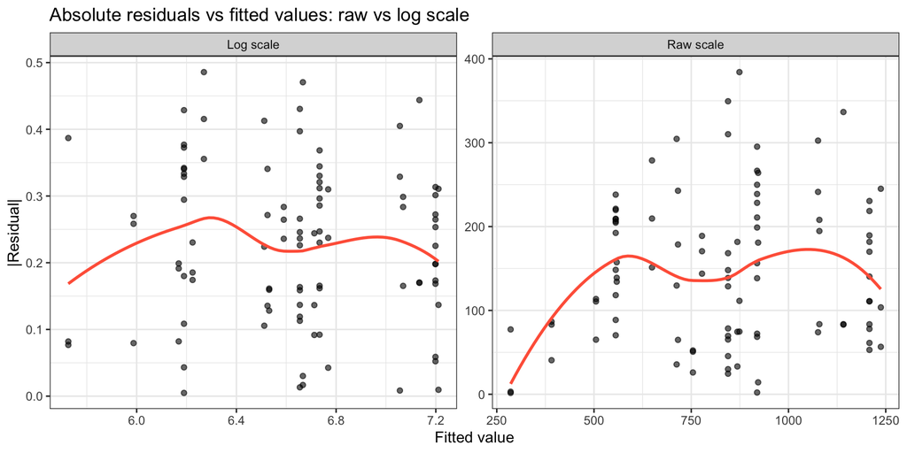

Absolute residuals vs fitted values from a Gaussian model. The raw scale shows a mild increase in spread with the fitted value; the log scale is flatter. This supports modelling log(total weight).

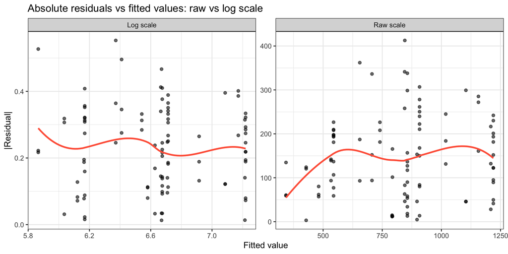

Absolute residuals vs fitted values from a Gaussian model. The raw scale shows a mild increase in spread with the fitted value; the log scale is flatter. This supports modelling log(total weight).

While log transformation was unable to address the bimodial nature of total weight distribution, it looks like it stabalizes variance.

## 3) Interations

Healthy Fruit Weight by Heat Treatment

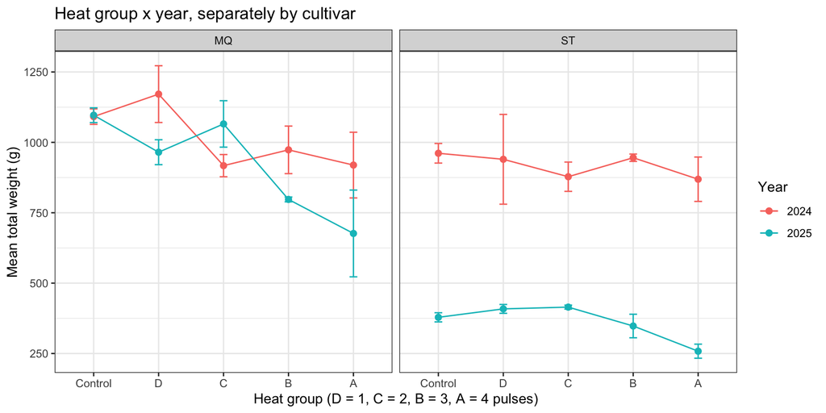

Mean total weight by heat group and year, separately for each cultivar. The 2024 and 2025 profiles differ: 2025 is lower overall, and MQ declines sharply at B/A in 2025 while ST is flatter. This supports a heat_group x year interaction.

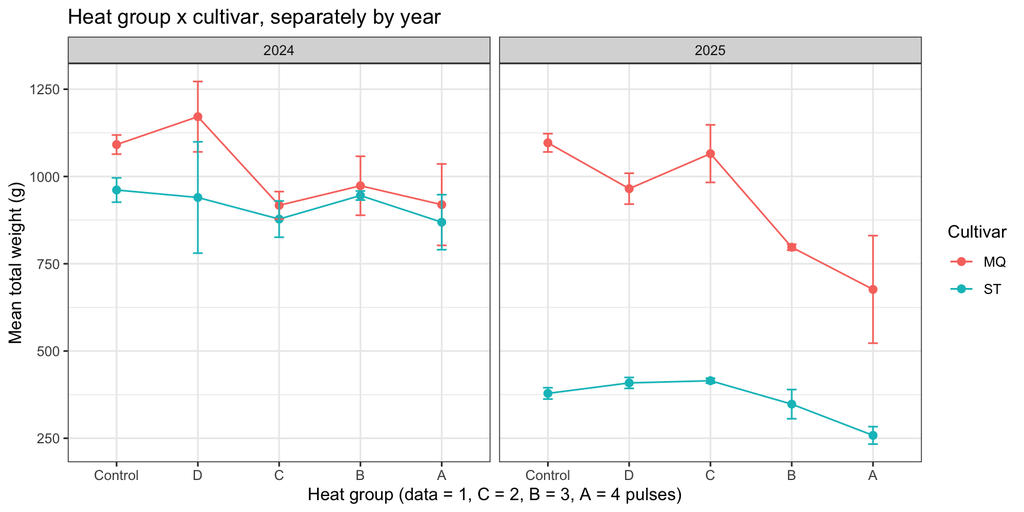

Mean total weight by heat group and cultivar, separately by year. MQ and ST differ mainly in level; their heat profiles are similar enough that a heat_group x cultivar interaction is not obviously required, but it is tested in H1.

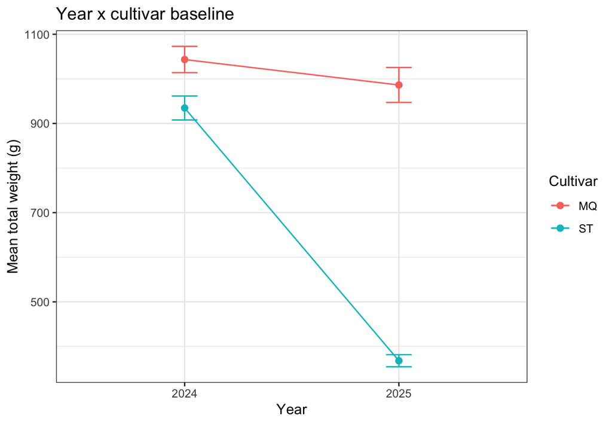

Mean total weight by year and cultivar. The large 2025 ST drop supports a year x cultivar baseline term.

The figures support the following model structure:

- **log(total_weight)** rather than raw weight: the response is positive, the effects are naturally multiplicative, and the log-scale residuals are more homogeneous.
- **(1 | pair_id)**: control and heat plots in the same pair_id are strongly correlated, so the pair_id must be a random effect.
- **heat_group × year**: the 2024 and 2025 profiles have different shapes, especially for MQ; ST is much lower in 2025.
- **year:cultivar**: 2025 ST is much lower than 2024 ST, a baseline shift that is not a heat effect.
- **heat_group × cultivar**: MQ and ST differ mainly in level; their heat profiles are similar enough that the interaction is tested but not obviously required.

The model-building section below fits the candidate models H0–H4 and compares them with AIC and likelihood-ratio tests.

pair_id structure

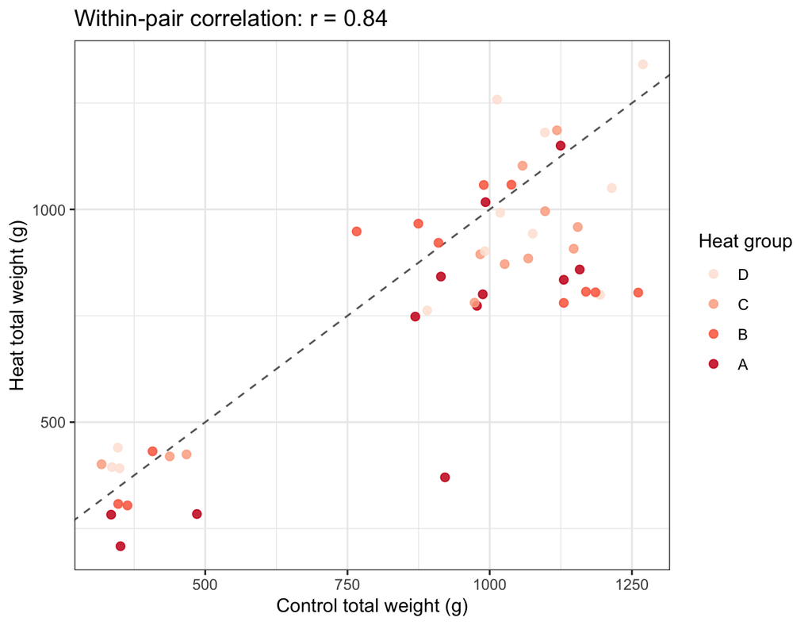

Control and heat total weights within the same pair_id are strongly correlated (r = 0.84). This supports the pair_id random intercept (1 | pair_id).

Because r=0.84 represents a strong positive correlation, plants in the same pair tend to naturally start or grow at similar sizes (likely due to shared microclimate, soil, or location). Model Justification: This high correlation proves that observations within a pair are not independent. Mixed Model Syntax: It validates using a mixed-effects model with a random intercept for pairs - lmer(total_weight ~ heat_group + (1 | pair_id))—to control for pair-level baseline differences and avoid artificially inflated sample sizes/p-values.

## 4) How does heat stress affect yield as measured by the total weight of fruit?

### 4.1 Candidate models

AIC comparison for total weight (ML fits).

| Model | df | AIC | dAIC |
| --- | --- | --- | --- |
| H0 | 10 | -71.59 | 13.01 |
| H1 | 14 | -68.64 | 15.96 |
| H2 | 14 | -84.60 | 0.00 |
| H3 | 18 | -83.69 | 0.91 |
| H4 | 13 | -66.65 | 17.95 |

H2 has the smallest AIC, so we select H2.

### 4.2 Heteroscedastic residual variance

H2 assumes a common residual variance. Control and heat plots may differ in their residual spread, so we refit the same fixed and random effects with `nlme::lme` and allow a separate residual variance for Control and OTC:

```
##        Model df       AIC       BIC   logLik   Test  L.Ratio p-value
## h2_hom     1 14 -33.91285  0.118586 30.95642
## h2_het     2 15 -39.92700 -3.464752 34.96350 1 vs 2 8.014156  0.0046
```

The likelihood-ratio test is significant, so the model with separate residual variances is preferred. We use `h2_het` for the final estimates.

### 4.3 Coefficients of the final model

Fixed-effect estimates of the final heteroscedastic H2 model.

| Term | Estimate | SE | p_value | Ratio | Lower_95 | Upper_95 |
| --- | --- | --- | --- | --- | --- | --- |
| (Intercept) | 6.987 | 0.031 | < 1e-04 | 1082.535 | 1016.681 | 1152.654 |
| heat_groupD | -0.006 | 0.072 | 0.93396 | 0.994 | 0.859 | 1.150 |
| heat_groupC | -0.140 | 0.072 | 0.05976 | 0.870 | 0.752 | 1.006 |
| heat_groupB | -0.044 | 0.072 | 0.54507 | 0.957 | 0.827 | 1.107 |
| heat_groupA | -0.135 | 0.072 | 0.06883 | 0.874 | 0.755 | 1.011 |
| year2025 | -0.012 | 0.044 | 0.79197 | 0.988 | 0.904 | 1.080 |
| cultivarST | -0.121 | 0.042 | 0.00636 | 0.886 | 0.814 | 0.965 |
| heat_groupD:year2025 | 0.001 | 0.102 | 0.99550 | 1.001 | 0.814 | 1.230 |
| heat_groupC:year2025 | 0.160 | 0.102 | 0.12503 | 1.173 | 0.955 | 1.442 |
| heat_groupB:year2025 | -0.167 | 0.102 | 0.10883 | 0.846 | 0.688 | 1.040 |
| heat_groupA:year2025 | -0.321 | 0.102 | 0.00311 | 0.725 | 0.590 | 0.891 |
| year2025:cultivarST | -0.906 | 0.060 | < 1e-04 | 0.404 | 0.358 | 0.456 |

The reference levels are Control, 2024 and MQ. The `heat_group` coefficients are log ratios relative to Control in 2024 for MQ; the `:year2025` terms add the extra change in 2025; `cultivarST` is the ST/MQ baseline difference in 2024; `year2025:cultivarST` is the extra 2025 change for ST.

### 4.4 Answer

Heat stress lowers total fruit weight, but how big the drop is depends on the year and on how many pulses the plants get. On average, the four heat levels are about 11.5% lower than Control. The drop is smaller in 2024 (about 7.8%) and larger in 2025 (about 15.1%). In 2025, A is about 36.6% lower and B about 19.1% lower. Each pulse trend points are about −9% per pulse overall, but it is weak in 2024 (−3%, p = 0.36) and strong in 2025 (−15%, p < 0.0001). We do not see a heat × cultivar interaction for p=0.28; MQ and ST differ mostly in baseline, and the 2025 ST baseline is much lower. We also let Control and OTC have different residual variances; the LRT supports this, so we use that model for the final estimates.

## 5) How does heat stress affect yield as measured by the total weight of healthy fruit?

### Data and first look

**Healthy weight across cultivars and years.** Healthy fruit weight is the total weight, in grams, of the healthy berries harvested from a plot. All 96 plots (48 pairs of a heated plot and its neighbouring Control plot) were used, and no observations were removed. Healthy weight differed strongly between the four combinations of cultivar and year. Control plots of Stevens in 2025 produced on average only 374 g of healthy fruit, compared with 945 to 1060 g in the other three combinations.

**Comparing each heated plot with its own Control.** [Figure: log ratio] shows the ratio of healthy fruit weight between each heated plot and its neighbouring Control plot. In 37 of the 48 pairs (77%), the heated plot produced less healthy fruit than its Control, so heat reduced healthy weight in most pairs. The pattern across heat intensities differed between years. In 2024, the ratios were similar for all four intensities: in most groups, heated plots produced about 15 to 25% less healthy fruit than their Controls, and there was no tendency for more pulses to cause a larger reduction. In 2025, the ratios decreased as the number of heat pulses increased, and heated plots that received three or four pulses produced clearly less healthy fruit than those that received one or two.

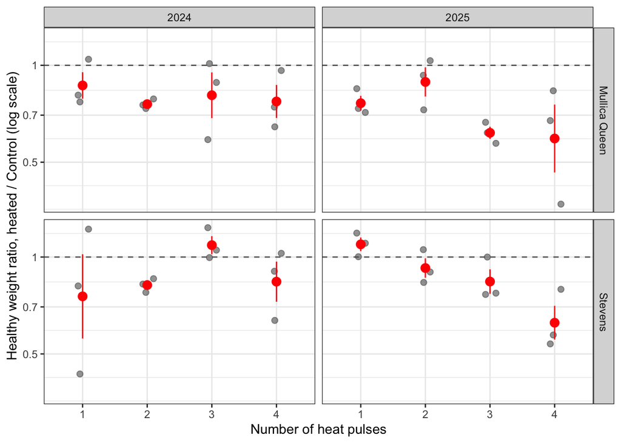

Ratio of healthy fruit weight in each heated (OTC) plot to that in its paired Control plot, by number of heat pulses, cultivar (rows) and year (columns). Grey points are the 48 individual pairs; red points and bars show the mean and plus or minus one standard error of the log ratios. The dashed line marks a ratio of 1 (no difference); points below it are pairs in which the heated plot produced less healthy fruit than its own Control. The vertical axis is on a logarithmic scale.

### Model

**Response scale.** We modelled the natural logarithm of healthy weight. On the original scale, groups with a higher mean healthy weight also varied more (Spearman correlation between group mean and group standard deviation 0.44 across the 20 combinations of cultivar, year and heat group), which violates the model’s assumption of equal variance; on the log scale this association was much weaker (-0.22). On the log scale, the model treats the effect of heat as a proportional change, so we report each effect as the ratio of healthy weight in heated plots to that in Control plots; a ratio of 0.80 means 20% less healthy fruit.

**Accounting for the pairs.** The two plots of a pair are neighbours and share growing conditions, so they are not independent. We therefore included a random effect for each pair, which allows every pair to have its own baseline. The correlation between the log healthy weights of the two plots of a pair was 0.85 overall, but this mostly reflects the large baseline differences between cultivar–year combinations; within each combination it ranged from -0.18 to 0.46. But we kept the pair effect because it reflects how the experiment was designed.

**Pooling the Control plots.** All Control plots received the same treatment, regardless of how many pulses their paired heated plot received. We therefore treated the 12 Control plots of each cultivar–year combination as a single Control group, so that the heat treatment has five levels: Control and 1, 2, 3 or 4 heat pulses.

**Choosing the model.** We compared six candidate models that differed only in how the heat effect was allowed to vary between cultivars and years ([Table: model comparison] in the appendix), using likelihood-ratio tests and the Akaike and Bayesian information criteria (AIC and BIC). There was strong evidence that heat affected healthy weight (p < 0.001). Allowing the heat effect to differ between years improved the fit (p = 0.0064), whereas allowing it to differ between cultivars did not (p = 0.29). We therefore selected the model with a year-specific heat effect, which also had the lowest AIC; BIC, which penalises additional parameters more heavily, preferred the simpler model with a common heat effect.

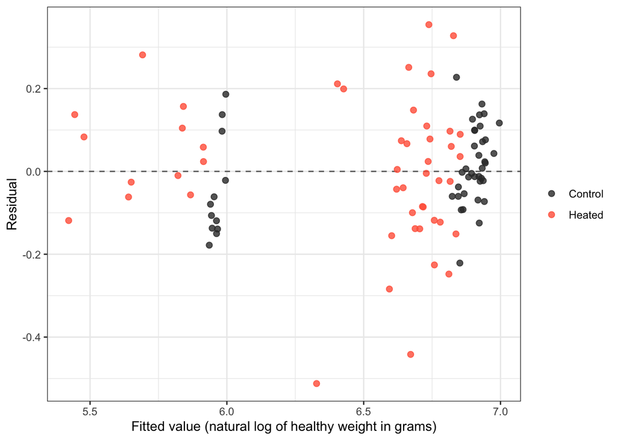

Residuals against fitted values from the selected model fitted with a single residual variance for all plots. Each point is one plot; black points are Control plots and red points are heated plots. The dashed line marks zero. The residuals of heated plots are clearly more spread out than those of Control plots.

**Unequal variances in heated and Control plots.** When the selected model was fitted with the same residual variance for all plots, the residuals of heated plots were clearly more spread out than those of Control plots ([Figure: residuals]). Ignoring this would understate the uncertainty of comparisons involving heated plots, so we refitted the model with separate residual variances for heated and Control plots, which fitted much better (likelihood-ratio test, p < 0.001); the estimated residual standard deviation of heated plots was about 2.3 times that of Control plots. With this change, the residuals had a similar spread in both groups and both the residuals and the estimated pair effects were close to normally distributed ([Figure: final diagnostics] in the appendix), apart from two heated plots with unusually low healthy weight, which we examine in the sensitivity analysis.

**Final model.** The final model for plot $i$ is

$$\log(Y_i) = \mu + \alpha_{g(i)} + \beta_{t(i)} +
(\alpha\beta)_{g(i)\,t(i)} + \gamma_{c(i)} + (\beta\gamma)_{t(i)\,c(i)}
+ b_{k(i)} + \varepsilon_i,$$

where $Y_i$ is the healthy fruit weight in grams, $\log$ is the natural logarithm, $\mu$ is the overall intercept, $\alpha_{g}$ is the effect of heat group $g$ (Control or 1, 2, 3 or 4 pulses), $\beta_{t}$ is the effect of year $t$, $\gamma_{c}$ is the effect of cultivar $c$, $(\alpha\beta)_{gt}$ allows the heat effect to differ between years, and $(\beta\gamma)_{tc}$ allows the cultivar baseline to differ between years. The term $b_{k}$ is the random effect of pair $k$, with $b_k \sim N(0, \sigma_b^2)$, and $\varepsilon_i$ is the residual error, with $\varepsilon_i \sim N(0, \sigma^2_{\text{Control}})$ for Control plots and $\varepsilon_i \sim N(0, \sigma^2_{\text{Heated}})$ for heated plots. The estimated standard deviations are $\hat\sigma_b = 0.062$, $\hat\sigma_{\text{Control}} = 0.093$ and $\hat\sigma_{\text{Heated}} = 0.212$. The model was fitted by restricted maximum likelihood with the nlme package in R. The estimated coefficients are listed in [Table: coefficients] in the appendix.

### Results

**Overall effect of heat.** Averaged over the four heat groups, both cultivars and both years, heated plots produced 20% less healthy fruit than Control plots (95% CI 14% to 25%, p < 0.001). The average reduction was similar in the two years, 17% in 2024 and 22% in 2025 ([Table: results]).

Estimated effect of heat on healthy fruit weight in each year, averaged over the two cultivars. Each estimate is the ratio of healthy weight in heated plots to that in Control plots; a ratio of 0.80 means 20% less healthy fruit. For the individual heat groups, confidence intervals and p-values are adjusted for comparing four heat groups with the same Control using Dunnett’s method. The last row is the multiplicative change in healthy weight for each additional heat pulse among heated plots, estimated as a straight-line trend across 1 to 4 pulses.

| Comparison | 2024: ratio (95% CI) | 2024: p-value | 2025: ratio (95% CI) | 2025: p-value |
| --- | --- | --- | --- | --- |
| Average of the four heat groups vs Control | 0.83 (0.76 to 0.92) | < 0.001 | 0.78 (0.71 to 0.85) | < 0.001 |
| 1 pulse vs Control | 0.84 (0.66 to 1.06) | 0.176 | 0.89 (0.71 to 1.12) | 0.505 |
| 2 pulses vs Control | 0.80 (0.64 to 1.01) | 0.065 | 0.93 (0.74 to 1.17) | 0.785 |
| 3 pulses vs Control | 0.90 (0.71 to 1.13) | 0.565 | 0.73 (0.58 to 0.93) | 0.006 |
| 4 pulses vs Control | 0.80 (0.63 to 1.00) | 0.056 | 0.60 (0.47 to 0.75) | < 0.001 |
| Each additional pulse (from 1 to 4 pulses) | 1.00 (0.92 to 1.08) | 0.930 | 0.87 (0.80 to 0.94) | < 0.001 |

**Individual heat groups and dose response.** In 2025, the reduction grew with the number of pulses: plots that received three and four pulses produced 27% and 40% less healthy fruit than Control, while one or two pulses had no statistically discernible effect. Across the four heat groups, each additional pulse reduced healthy weight by about 13% (95% CI 6% to 20%), with no evidence of curvature. In 2024, all four heat groups were 10 to 20% below Control, but none was individually statistically discernible after adjustment, and there was no trend with the number of pulses. The two years therefore differ mainly in the dose response rather than in the average size of the effect (exploratory comparison of the two slopes, p = 0.018), although the overall test of a year difference was only marginal (p = 0.077).

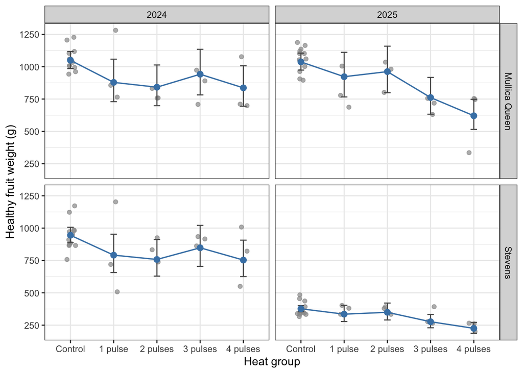

Estimated healthy fruit weight by heat group, cultivar (rows) and year (columns). Blue points are the means estimated by the final model, joined by lines, with 95% confidence intervals shown as bars; grey points are the individual plots. The model assumes that heat reduces healthy weight by the same proportion in both cultivars, so the estimated curves of the two cultivars have the same shape on a proportional scale.

**Cultivars.** There was no evidence that the proportional effect of heat differed between Mullica Queen and Stevens, but because their baselines differ, the same proportional reduction means very different losses in grams ([Figure: estimates]). In 2025, for example, four pulses reduced the estimated healthy weight of Mullica Queen from 1037 g to 621 g, but that of Stevens only from 377 g to 225 g.

### Sensitivity analysis and limitations

**Sensitivity to extreme plots.** To check whether our conclusions depend on the two heated plots with unusually low healthy weight, we removed the 2 pairs containing them (4 plots, 4.2% of the data) and refitted the final model. The estimated effects became slightly smaller, but all main conclusions were unchanged: the average reduction was 14% in 2024 and 20% in 2025, and the reduction per additional pulse in 2025 was 10%. The only change was that two heat groups in 2024 became individually statistically discernible, which confirms that the evidence for individual heat groups in 2024 is borderline.

**Limitations.** Only the heat treatment was assigned by the experimenters, so only its effects can be interpreted as causal; each cultivar was grown in a single field, so cultivar differences cannot be separated from field differences, and year differences may reflect weather or other unmeasured conditions. With three pairs per heat group in each cultivar and year, comparisons of individual heat groups have limited precision. The final model and the comparison of slopes between years were chosen after examining the data, so the corresponding p-values are likely to be somewhat optimistic. Finally, with only two years of data, we cannot tell whether the dose response seen in 2025 or its absence in 2024 is more typical.

### Answer

Heat stress reduced the total weight of healthy fruit by about 20% on average (95% CI 14% to 25%), with a similar average reduction in 2024 and 2025. The effect of the number of pulses, however, differed between years: in 2025 the reduction grew by about 13% with each additional pulse and reached about 40% with four pulses, whereas in 2024 the number of pulses made little difference. The proportional effect was similar for both cultivars, so losses in grams were larger for Mullica Queen, which has the higher baseline. Because this reduction is larger than that for total fruit weight (Section 4), heat appears to lower healthy weight partly by increasing the share of rotten fruit.

## 6) How does heat stress affect yield as measured by the percentage of healthy berries by count?

First, we investigate the distribution of the healthy berries by count (n_healthy) variable

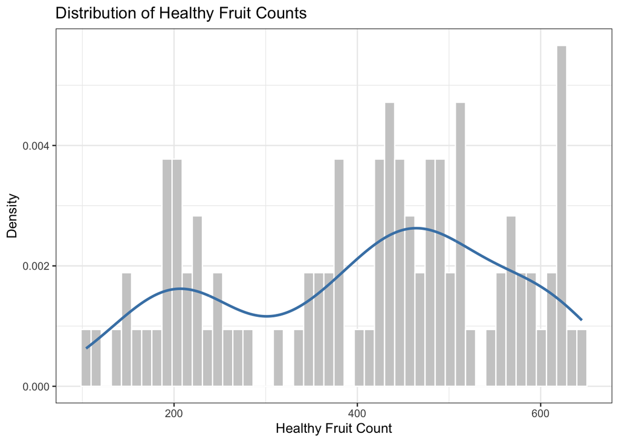

Let’s look at interaction plot

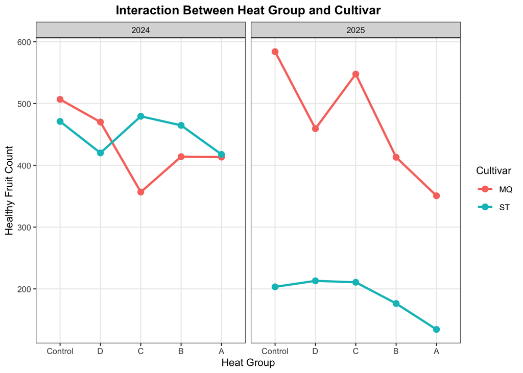

- Note (Soren) : effect of heat group differ by culttivar
- Slopes differ across groups showing a possible heat group x cultivar interaction
- Patterns differ across - a possible heat group x culticar x year interaction

# Model Generation

```
##  Family: nbinom2  ( log )
## Formula:
## healthy_n ~ heat_group + cultivar + factor(year) + (1 | pair_id)
## Data: data
##
##       AIC       BIC    logLik -2*log(L)  df.resid
##    1175.9    1199.0    -579.0    1157.9        87
##
## Random effects:
##
## Conditional model:
##  Groups  Name        Variance Std.Dev.
##  pair_id (Intercept) 0.06198  0.249
## Number of obs: 96, groups:  pair_id, 48
##
## Dispersion parameter for nbinom2 family (): 32.9
##
## Conditional model:
##                  Estimate Std. Error z value Pr(>|z|)
## (Intercept)       6.45584    0.07261   88.91  < 2e-16 ***
## heat_groupD      -0.12947    0.06965   -1.86   0.0630 .
## heat_groupC      -0.11745    0.06949   -1.69   0.0910 .
## heat_groupB      -0.14598    0.07013   -2.08   0.0374 *
## heat_groupA      -0.30171    0.07041   -4.28 1.83e-05 ***
## cultivarST       -0.48475    0.08104   -5.98 2.21e-09 ***
## factor(year)2025 -0.38285    0.08105   -4.72 2.31e-06 ***
## ---
## Signif. codes:  0 '***' 0.001 '**' 0.01 '*' 0.05 '.' 0.1 ' ' 1
```

```
##  Family: nbinom2  ( log )
## Formula:
## healthy_n ~ heat_group * cultivar * factor(year) + (1 | pair_id)
## Data: data
##
##       AIC       BIC    logLik -2*log(L)  df.resid
##    1109.3    1165.7    -532.6    1065.3        74
##
## Random effects:
##
## Conditional model:
##  Groups  Name        Variance Std.Dev.
##  pair_id (Intercept) 0.006145 0.07839
## Number of obs: 96, groups:  pair_id, 48
##
## Dispersion parameter for nbinom2 family (): 52.4
##
## Conditional model:
##                                         Estimate Std. Error z value Pr(>|z|)
## (Intercept)                              6.22716    0.04765  130.69  < 2e-16
## heat_groupD                             -0.09040    0.10054   -0.90 0.368561
## heat_groupC                             -0.34390    0.10142   -3.39 0.000696
## heat_groupB                             -0.19746    0.10081   -1.96 0.050149
## heat_groupA                             -0.21340    0.10084   -2.12 0.034321
## cultivarST                              -0.07370    0.06751   -1.09 0.274944
## factor(year)2025                         0.14289    0.06722    2.13 0.033536
## heat_groupD:cultivarST                  -0.05899    0.14293   -0.41 0.679806
## heat_groupC:cultivarST                   0.33573    0.14394    2.33 0.019675
## heat_groupB:cultivarST                   0.21041    0.14331    1.47 0.142053
## heat_groupA:cultivarST                   0.11118    0.14420    0.77 0.440700
## heat_groupD:factor(year)2025            -0.15309    0.14180   -1.08 0.280319
## heat_groupC:factor(year)2025             0.27846    0.14220    1.96 0.050200
## heat_groupB:factor(year)2025            -0.16449    0.14283   -1.15 0.249459
## heat_groupA:factor(year)2025            -0.29541    0.14350   -2.06 0.039533
## cultivarST:factor(year)2025             -0.98768    0.09663  -10.22  < 2e-16
## heat_groupD:cultivarST:factor(year)2025  0.36382    0.20511    1.77 0.076103
## heat_groupC:cultivarST:factor(year)2025 -0.25160    0.20343   -1.24 0.216160
## heat_groupB:cultivarST:factor(year)2025  0.03539    0.20544    0.17 0.863219
## heat_groupA:cultivarST:factor(year)2025 -0.02577    0.20919   -0.12 0.901943
##
## (Intercept)                             ***
## heat_groupD
## heat_groupC                             ***
## heat_groupB                             .
## heat_groupA                             *
## cultivarST
## factor(year)2025                        *
## heat_groupD:cultivarST
## heat_groupC:cultivarST                  *
## heat_groupB:cultivarST
## heat_groupA:cultivarST
## heat_groupD:factor(year)2025
## heat_groupC:factor(year)2025            .
## heat_groupB:factor(year)2025
## heat_groupA:factor(year)2025            *
## cultivarST:factor(year)2025             ***
## heat_groupD:cultivarST:factor(year)2025 .
## heat_groupC:cultivarST:factor(year)2025
## heat_groupB:cultivarST:factor(year)2025
## heat_groupA:cultivarST:factor(year)2025
## ---
## Signif. codes:  0 '***' 0.001 '**' 0.01 '*' 0.05 '.' 0.1 ' ' 1
```

```
## Data: data
## Models:
## m1: healthy_n ~ heat_group + cultivar + factor(year) + (1 | pair_id), zi=~0, disp=~1
## m2: healthy_n ~ heat_group * cultivar * factor(year) + (1 | pair_id), zi=~0, disp=~1
##    Df    AIC    BIC  logLik deviance  Chisq Chi Df Pr(>Chisq)
## m1  9 1175.9 1199.0 -578.95   1157.9
## m2 22 1109.3 1165.7 -532.65   1065.3 92.606     13  4.427e-14 ***
## ---
## Signif. codes:  0 '***' 0.001 '**' 0.01 '*' 0.05 '.' 0.1 ' ' 1
```

```
##  Family: nbinom2  ( log )
## Formula:
## healthy_n ~ (heat_group + cultivar + factor(year))^2 + (1 | pair_id)
## Data: data
##
##       AIC       BIC    logLik -2*log(L)  df.resid
##    1106.5    1152.7    -535.3    1070.5        78
##
## Random effects:
##
## Conditional model:
##  Groups  Name        Variance Std.Dev.
##  pair_id (Intercept) 0.005143 0.07171
## Number of obs: 96, groups:  pair_id, 48
##
## Dispersion parameter for nbinom2 family (): 46.7
##
## Conditional model:
##                              Estimate Std. Error z value Pr(>|z|)
## (Intercept)                   6.23071    0.04637  134.38  < 2e-16 ***
## heat_groupD                  -0.17254    0.09086   -1.90  0.05757 .
## heat_groupC                  -0.28024    0.09230   -3.04  0.00239 **
## heat_groupB                  -0.20554    0.09113   -2.26  0.02411 *
## heat_groupA                  -0.20767    0.09155   -2.27  0.02330 *
## cultivarST                   -0.08041    0.06192   -1.30  0.19407
## factor(year)2025              0.13601    0.06174    2.20  0.02761 *
## heat_groupD:cultivarST        0.11981    0.10590    1.13  0.25791
## heat_groupC:cultivarST        0.21631    0.10692    2.02  0.04306 *
## heat_groupB:cultivarST        0.22081    0.10874    2.03  0.04228 *
## heat_groupA:cultivarST        0.09737    0.10740    0.91  0.36458
## heat_groupD:factor(year)2025  0.01824    0.10755    0.17  0.86536
## heat_groupC:factor(year)2025  0.15492    0.10561    1.47  0.14241
## heat_groupB:factor(year)2025 -0.14583    0.10646   -1.37  0.17072
## heat_groupA:factor(year)2025 -0.30638    0.10744   -2.85  0.00435 **
## cultivarST:factor(year)2025  -0.97237    0.07605  -12.79  < 2e-16 ***
## ---
## Signif. codes:  0 '***' 0.001 '**' 0.01 '*' 0.05 '.' 0.1 ' ' 1
```

```
## Data: data
## Models:
## m_add: healthy_n ~ heat_group + cultivar + factor(year) + (1 | pair_id), zi=~0, disp=~1
## m_2way: healthy_n ~ (heat_group + cultivar + factor(year))^2 + (1 | pair_id), zi=~0, disp=~1
## m_3way: healthy_n ~ heat_group * cultivar * factor(year) + (1 | pair_id), zi=~0, disp=~1
##        Df    AIC    BIC  logLik deviance   Chisq Chi Df Pr(>Chisq)
## m_add   9 1175.9 1199.0 -578.95   1157.9
## m_2way 18 1106.5 1152.7 -535.27   1070.5 87.3562      9  5.514e-15 ***
## m_3way 22 1109.3 1165.7 -532.65   1065.3  5.2497      4     0.2626
## ---
## Signif. codes:  0 '***' 0.001 '**' 0.01 '*' 0.05 '.' 0.1 ' ' 1
```

From the first anova, we show that there is strong evidence that the association between heat group and healthy fruit count depends on cultivar, year or their combination. But when we add a 2 way interaction model, we see that 2 way interaction model does way better.

– One important detail: because nbinom2 uses a log link, the coefficients are on the log expected-count scale. Exponentiating a coefficient gives a count ratio.

heat_groupD, pvalue ( 0.0576 ), About 15.8% fewer healthy fruits than Control; borderline evidence

percentages are calculated as (exp(beta) - 1 ) * 100

What the model concludes : Healthy fruit counts differ across several heat groups relative to Control. The heat-group effects for C and B differ between cultivars. The A-versus-Control effect differs between years. The cultivar difference changes substantially between years.

There is no statistically significant evidence that the full three-way interaction improves model fit ($p=0.263$, from your earlier comparison).

# TODO : look into this one more

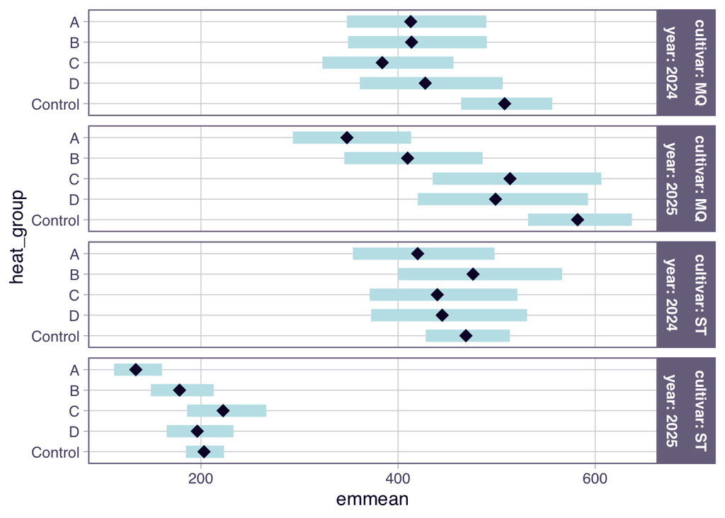

```
## cultivar = MQ, year = 2024:
##  contrast    ratio     SE  df null z.ratio p.value
##  D / Control 0.842 0.0765 Inf    1  -1.899  0.1817
##  C / Control 0.756 0.0697 Inf    1  -3.036  0.0090
##  B / Control 0.814 0.0742 Inf    1  -2.255  0.0824
##  A / Control 0.812 0.0744 Inf    1  -2.268  0.0798
##
## cultivar = ST, year = 2024:
##  contrast    ratio     SE  df null z.ratio p.value
##  D / Control 0.949 0.0893 Inf    1  -0.560  0.9105
##  C / Control 0.938 0.0852 Inf    1  -0.704  0.8497
##  B / Control 1.015 0.0952 Inf    1   0.163  0.9952
##  A / Control 0.896 0.0823 Inf    1  -1.201  0.5547
##
## cultivar = MQ, year = 2025:
##  contrast    ratio     SE  df null z.ratio p.value
##  D / Control 0.857 0.0789 Inf    1  -1.676  0.2768
##  C / Control 0.882 0.0788 Inf    1  -1.403  0.4272
##  B / Control 0.704 0.0642 Inf    1  -3.850  0.0005
##  A / Control 0.598 0.0551 Inf    1  -5.582 <0.0001
##
## cultivar = ST, year = 2025:
##  contrast    ratio     SE  df null z.ratio p.value
##  D / Control 0.966 0.0896 Inf    1  -0.372  0.9658
##  C / Control 1.095 0.1050 Inf    1   0.951  0.7139
##  B / Control 0.878 0.0843 Inf    1  -1.359  0.4538
##  A / Control 0.659 0.0635 Inf    1  -4.323 <0.0001
##
## P value adjustment: dunnettx method for 4 tests
## Tests are performed on the log scale
```

```
## [1] "contrast" "cultivar" "year"     "ratio"    "SE"       "df"       "null"
## [8] "z.ratio"  "p.value"
```

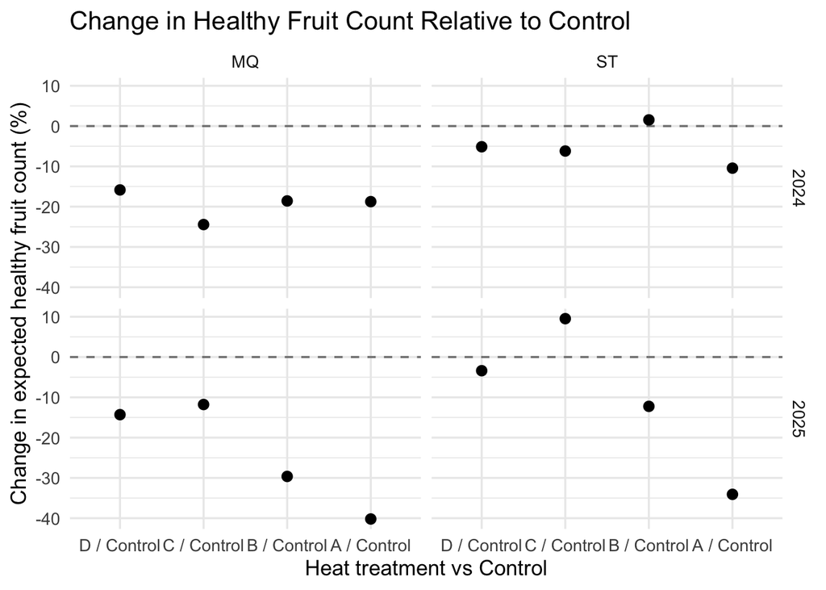

How big is the difference between the controls and the heat treatments ? - contrast above shows it and there is a plot too ( TODO : look into the plot more)

Model Odds Ratios and 95% Confidence Intervals

|  | Term | Odds Ratio | 95% CI Lower | 95% CI Upper | p-value |
| --- | --- | --- | --- | --- | --- |
| (Intercept) | (Intercept) | 636.41 | 551.99 | 733.74 | < 0.001 |
| heat_groupD | heat_groupD | 0.88 | 0.77 | 1.01 | 0.063 |
| heat_groupC | heat_groupC | 0.89 | 0.78 | 1.02 | 0.091 |
| heat_groupB | heat_groupB | 0.86 | 0.75 | 0.99 | 0.037 |
| heat_groupA | heat_groupA | 0.74 | 0.64 | 0.85 | < 0.001 |
| cultivarST | cultivarST | 0.62 | 0.53 | 0.72 | < 0.001 |
| factor(year)2025 | factor(year)2025 | 0.68 | 0.58 | 0.80 | < 0.001 |

## 7) How does heat stress affect yield as measured by the percentage of healthy fruit by weight?

binomial model underpredict heritabiltiy

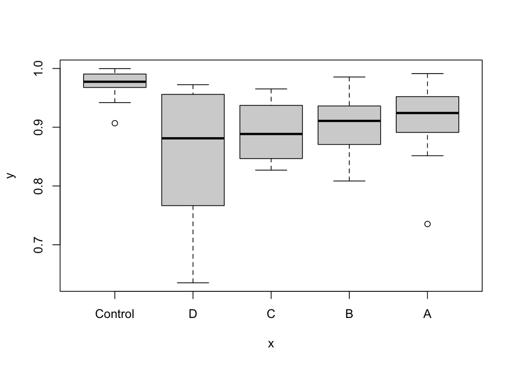

```
##  Family: beta  ( logit )
## Formula:          healthy_weight_prop ~ heat_group + cultivar + factor(year) +
##     (1 | pair_id)
## Data: data
##
##       AIC       BIC    logLik -2*log(L)  df.resid
##    -392.9    -369.8     205.4    -410.9        87
##
## Random effects:
##
## Conditional model:
##  Groups  Name        Variance Std.Dev.
##  pair_id (Intercept) 0.06685  0.2586
## Number of obs: 96, groups:  pair_id, 48
##
## Dispersion parameter for beta family (): 41.8
##
## Conditional model:
##                  Estimate Std. Error z value Pr(>|z|)
## (Intercept)       3.32263    0.20713  16.041  < 2e-16 ***
## heat_groupD      -1.67928    0.24953  -6.730 1.70e-11 ***
## heat_groupC      -1.46072    0.20468  -7.137 9.56e-13 ***
## heat_groupB      -1.35435    0.21442  -6.316 2.68e-10 ***
## heat_groupA      -1.20608    0.25170  -4.792 1.65e-06 ***
## cultivarST        0.60925    0.14287   4.264 2.01e-05 ***
## factor(year)2025  0.01113    0.14115   0.079    0.937
## ---
## Signif. codes:  0 '***' 0.001 '**' 0.01 '*' 0.05 '.' 0.1 ' ' 1
```

```
##  heat_group response     SE  df asymp.LCL asymp.UCL
##  Control       0.974 0.0046 Inf     0.964     0.982
##  D             0.876 0.0166 Inf     0.839     0.905
##  C             0.898 0.0157 Inf     0.863     0.925
##  B             0.907 0.0142 Inf     0.875     0.931
##  A             0.919 0.0129 Inf     0.890     0.941
##
## Results are averaged over the levels of: cultivar, year
## Confidence level used: 0.95
## Intervals are back-transformed from the logit scale
```

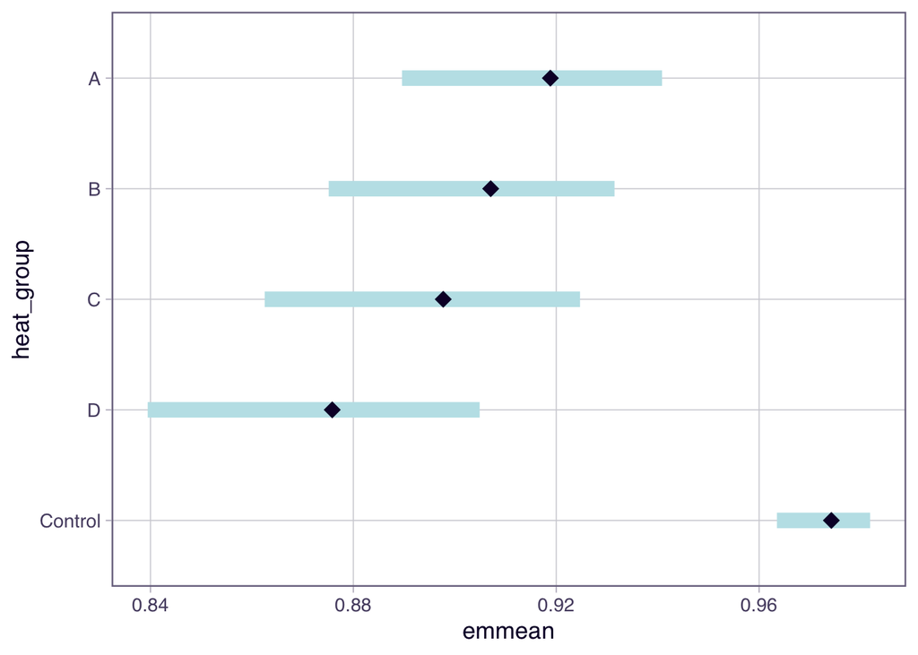

```
##                              Term Odds_Ratio   CI_Lower   CI_Upper      p_value
## (Intercept)           (Intercept) 27.7331821 18.4792710 41.6211976 6.600558e-58
## heat_groupD           heat_groupD  0.1865089  0.1143660  0.3041600 1.698841e-11
## heat_groupC           heat_groupC  0.2320683  0.1553789  0.3466089 9.555779e-13
## heat_groupB           heat_groupB  0.2581160  0.1695493  0.3929468 2.679090e-10
## heat_groupA           heat_groupA  0.2993679  0.1827910  0.4902930 1.653208e-06
## cultivarST             cultivarST  1.8390479  1.3898800  2.4333736 2.005567e-05
## factor(year)2025 factor(year)2025  1.0111895  0.7668041  1.3334620 9.371646e-01
```

```
##  heat_group response     SE  df asymp.LCL asymp.UCL
##  Control       0.974 0.0046 Inf     0.964     0.982
##  D             0.876 0.0166 Inf     0.839     0.905
##  C             0.898 0.0157 Inf     0.863     0.925
##  B             0.907 0.0142 Inf     0.875     0.931
##  A             0.919 0.0129 Inf     0.890     0.941
##
## Results are averaged over the levels of: cultivar, year
## Confidence level used: 0.95
## Intervals are back-transformed from the logit scale
```

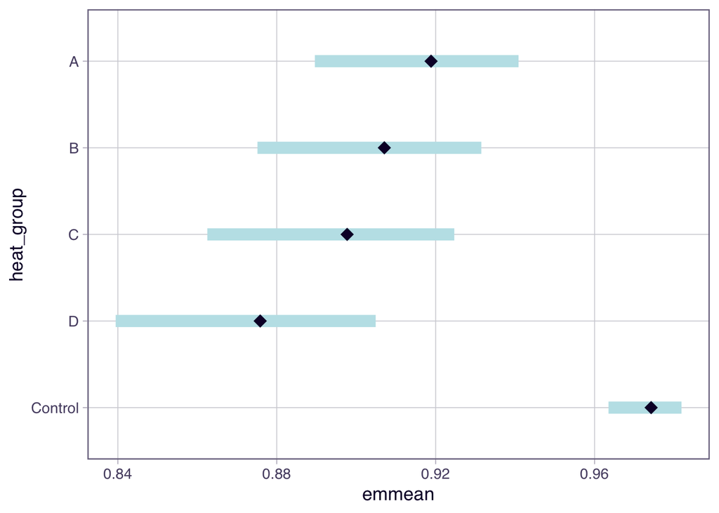

```
##  contrast    odds.ratio    SE  df null z.ratio p.value
##  Control / D      5.362 1.340 Inf    1   6.730 <0.0001
##  Control / C      4.309 0.882 Inf    1   7.137 <0.0001
##  Control / B      3.874 0.831 Inf    1   6.316 <0.0001
##  Control / A      3.340 0.841 Inf    1   4.792 <0.0001
##  D / C            0.804 0.191 Inf    1  -0.920  0.8893
##  D / B            0.723 0.168 Inf    1  -1.394  0.6317
##  D / A            0.623 0.141 Inf    1  -2.086  0.2260
##  C / B            0.899 0.203 Inf    1  -0.471  0.9899
##  C / A            0.775 0.191 Inf    1  -1.034  0.8399
##  B / A            0.862 0.210 Inf    1  -0.609  0.9737
##
## Results are averaged over the levels of: cultivar, year
## P value adjustment: tukey method for comparing a family of 5 estimates
## Tests are performed on the log odds ratio scale
```

```
##  Family: beta  ( logit )
## Formula:
## healthy_weight_prop_adj ~ heat_group + cultivar + factor(year) +
##     (1 | pair_id)
## Data: data
##
##       AIC       BIC    logLik -2*log(L)  df.resid
##    -392.9    -369.8     205.4    -410.9        87
##
## Random effects:
##
## Conditional model:
##  Groups  Name        Variance Std.Dev.
##  pair_id (Intercept) 0.06685  0.2586
## Number of obs: 96, groups:  pair_id, 48
##
## Dispersion parameter for beta family (): 41.8
##
## Conditional model:
##                  Estimate Std. Error z value Pr(>|z|)
## (Intercept)       3.32263    0.20713  16.041  < 2e-16 ***
## heat_groupD      -1.67928    0.24953  -6.730 1.70e-11 ***
## heat_groupC      -1.46072    0.20468  -7.137 9.56e-13 ***
## heat_groupB      -1.35435    0.21442  -6.316 2.68e-10 ***
## heat_groupA      -1.20608    0.25170  -4.792 1.65e-06 ***
## cultivarST        0.60925    0.14287   4.264 2.01e-05 ***
## factor(year)2025  0.01113    0.14115   0.079    0.937
## ---
## Signif. codes:  0 '***' 0.001 '**' 0.01 '*' 0.05 '.' 0.1 ' ' 1
```

```
##  heat_group response   SE  df asymp.LCL asymp.UCL
##  Control         409  9.9 Inf       391       429
##  D               368 17.7 Inf       335       405
##  C               371 17.9 Inf       337       407
##  B               347 16.7 Inf       316       381
##  A               300 14.5 Inf       273       330
##
## Results are averaged over the levels of: cultivar, year
## Confidence level used: 0.95
## Intervals are back-transformed from the log scale
```

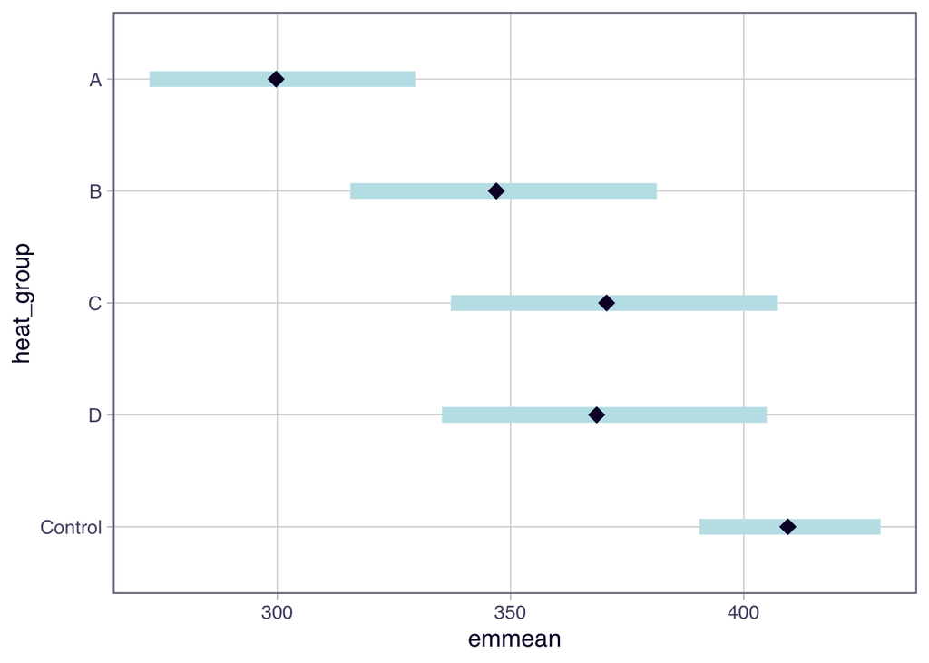

```
## cultivar = MQ:
##  heat_group response   SE  df asymp.LCL asymp.UCL
##  Control         544 18.3 Inf       509       581
##  D               460 30.6 Inf       404       524
##  C               443 29.5 Inf       389       505
##  B               411 27.5 Inf       361       469
##  A               379 25.4 Inf       332       432
##
## cultivar = ST:
##  heat_group response   SE  df asymp.LCL asymp.UCL
##  Control         308 10.7 Inf       288       330
##  D               295 20.3 Inf       258       338
##  C               310 21.7 Inf       270       356
##  B               293 20.7 Inf       255       336
##  A               237 16.6 Inf       207       272
##
## Results are averaged over the levels of: year
## Confidence level used: 0.95
## Intervals are back-transformed from the log scale
```

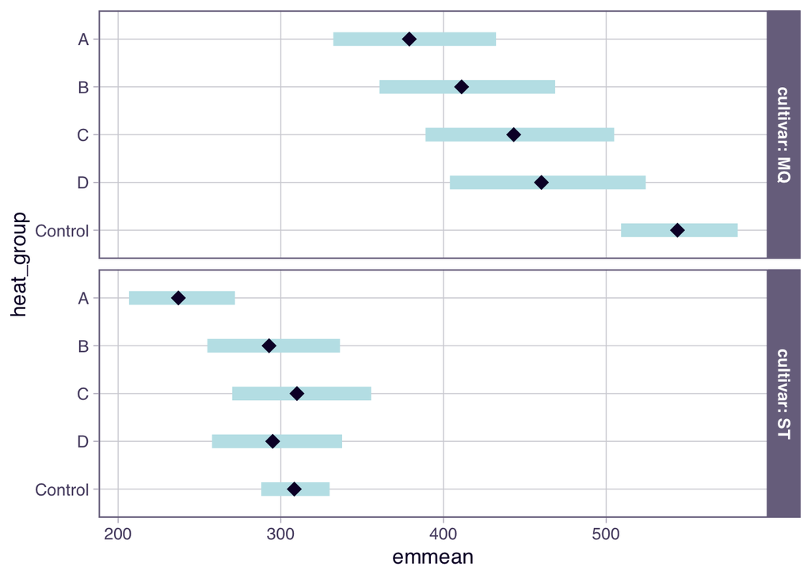

```
##  Family: betabinomial  ( logit )
## Formula:
## cbind(healthy_n, rotten_n) ~ heat_group + cultivar + factor(year) +
##     (1 | pair_id)
## Data: data
##
##       AIC       BIC    logLik -2*log(L)  df.resid
##     858.1     881.2    -420.1     840.1        87
##
## Random effects:
##
## Conditional model:
##  Groups  Name        Variance Std.Dev.
##  pair_id (Intercept) 0.06791  0.2606
## Number of obs: 96, groups:  pair_id, 48
##
## Dispersion parameter for betabinomial family (): 44.3
##
## Conditional model:
##                  Estimate Std. Error z value Pr(>|z|)
## (Intercept)        3.0034     0.1570  19.126  < 2e-16 ***
## heat_groupD       -1.2895     0.1919  -6.720 1.81e-11 ***
## heat_groupC       -1.2591     0.1708  -7.369 1.71e-13 ***
## heat_groupB       -1.2888     0.1700  -7.580 3.45e-14 ***
## heat_groupA       -1.4349     0.1874  -7.658 1.89e-14 ***
## cultivarST         0.1702     0.1272   1.338   0.1809
## factor(year)2025  -0.2635     0.1273  -2.070   0.0385 *
## ---
## Signif. codes:  0 '***' 0.001 '**' 0.01 '*' 0.05 '.' 0.1 ' ' 1
```

```
##  Family: betabinomial  ( logit )
## Formula:
## cbind(healthy_count_pct, (data$healthy_n + data$rotten_n) - healthy_n) ~
##     heat_group + cultivar + (1 | pair_id)
## Data: data
##
##       AIC       BIC    logLik -2*log(L)  df.resid
##     794.4     814.9    -389.2     778.4        88
##
## Random effects:
##
## Conditional model:
##  Groups  Name        Variance Std.Dev.
##  pair_id (Intercept) 0.04434  0.2106
## Number of obs: 96, groups:  pair_id, 48
##
## Dispersion parameter for betabinomial family (): 19.2
##
## Conditional model:
##             Estimate Std. Error z value Pr(>|z|)
## (Intercept)   1.2425     0.1116  11.137  < 2e-16 ***
## heat_groupD  -1.2982     0.1768  -7.344 2.07e-13 ***
## heat_groupC  -1.3009     0.1736  -7.494 6.68e-14 ***
## heat_groupB  -1.2534     0.1739  -7.208 5.66e-13 ***
## heat_groupA  -1.2686     0.1842  -6.888 5.65e-12 ***
## cultivarST    0.6207     0.1262   4.919 8.70e-07 ***
## ---
## Signif. codes:  0 '***' 0.001 '**' 0.01 '*' 0.05 '.' 0.1 ' ' 1
```

```
##  heat_group response     SE  df asymp.LCL asymp.UCL
##  Control       0.825 0.0142 Inf     0.796     0.851
##  D             0.563 0.0371 Inf     0.490     0.634
##  C             0.563 0.0381 Inf     0.487     0.635
##  B             0.574 0.0372 Inf     0.500     0.645
##  A             0.571 0.0384 Inf     0.494     0.644
##
## Results are averaged over the levels of: cultivar
## Unknown transformation "(": no transformation done
## Confidence level used: 0.95
```

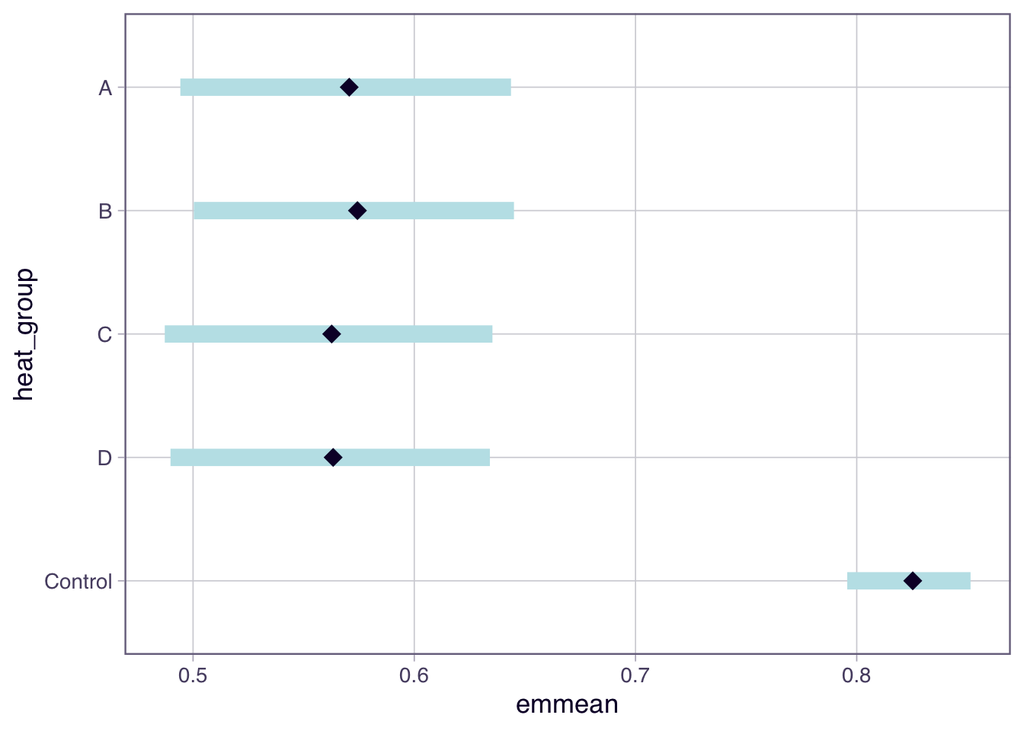

```
## , , heat_group = Control
##
##       cultivar
## year   MQ ST
##   2024 12 12
##   2025 12 12
##
## , , heat_group = D
##
##       cultivar
## year   MQ ST
##   2024  3  3
##   2025  3  3
##
## , , heat_group = C
##
##       cultivar
## year   MQ ST
##   2024  3  3
##   2025  3  3
##
## , , heat_group = B
##
##       cultivar
## year   MQ ST
##   2024  3  3
##   2025  3  3
##
## , , heat_group = A
##
##       cultivar
## year   MQ ST
##   2024  3  3
##   2025  3  3
```

[figure not shown]

3. How does heat stress affect yield as measured by the percentage of healthy berries by count?

## 8) Conclusion

## 9) Reference

## 10) Appendix

Candidate models for the natural logarithm of healthy fruit weight. All models include cultivar, year, the cultivar-by-year interaction and a random effect for each pair, and were fitted by maximum likelihood with a single residual variance. Parameters counts all estimated quantities, including the variances. Lower AIC and BIC indicate a better balance between fit and model size. The p-value is from a likelihood-ratio test of the model against the model named in the previous column.

| Model | Heat effect | Parameters | AIC | BIC | Likelihood-ratio test | p-value |
| --- | --- | --- | --- | --- | --- | --- |
| 1 | No heat effect | 6 | -11.8 | 3.6 |  |  |
| 2 | Same heat effect in all cultivars and years | 10 | -46.9 | -21.2 | vs. model 1 | < 0.001 |
| 3 | Heat effect differs between cultivars | 14 | -43.8 | -7.9 | vs. model 2 | 0.290 |
| 4 | Heat effect differs between years (selected) | 14 | -53.2 | -17.3 | vs. model 2 | 0.006 |
| 5 | Heat effect differs between cultivars and between years | 18 | -51.4 | -5.3 | vs. model 4 | 0.179 |
| 6 | Heat effect differs in every cultivar-year combination | 22 | -48.1 | 8.3 | vs. model 5 | 0.324 |

Estimated fixed effects of the final model. Estimates are on the natural log scale; Ratio is the exponential of the estimate, i.e. the multiplicative change in healthy weight. The reference levels are Control, 2024 and Mullica Queen. For the intercept, the exponential is the estimated healthy weight in grams of Control plots of Mullica Queen in 2024. The heat group terms compare each heat group with Control in 2024; the terms marked × 2025 give the additional multiplicative change in 2025. The p-values are not adjusted for multiple comparisons.

| Term | Estimate (log scale) | Standard error | Ratio | 95% CI for ratio | p-value |
| --- | --- | --- | --- | --- | --- |
| Intercept (Control, 2024, Mullica Queen) | 6.956 | 0.031 | 1049.56 | 985.47 to 1117.83 | < 0.001 |
| 1 pulse | -0.178 | 0.091 | 0.84 | 0.70 to 1.01 | 0.057 |
| 2 pulses | -0.221 | 0.091 | 0.80 | 0.67 to 0.96 | 0.019 |
| 3 pulses | -0.108 | 0.091 | 0.90 | 0.75 to 1.08 | 0.239 |
| 4 pulses | -0.227 | 0.091 | 0.80 | 0.66 to 0.96 | 0.016 |
| Year 2025 | -0.012 | 0.044 | 0.99 | 0.90 to 1.08 | 0.791 |
| Stevens | -0.105 | 0.043 | 0.90 | 0.83 to 0.98 | 0.018 |
| 1 pulse × 2025 | 0.061 | 0.128 | 1.06 | 0.82 to 1.38 | 0.638 |
| 2 pulses × 2025 | 0.146 | 0.128 | 1.16 | 0.89 to 1.50 | 0.262 |
| 3 pulses × 2025 | -0.201 | 0.128 | 0.82 | 0.63 to 1.06 | 0.125 |
| 4 pulses × 2025 | -0.287 | 0.128 | 0.75 | 0.58 to 0.97 | 0.031 |
| 2025 × Stevens | -0.908 | 0.061 | 0.40 | 0.36 to 0.46 | < 0.001 |

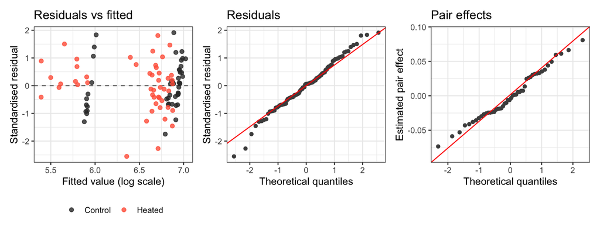

Diagnostic plots for the final model, which allows separate residual variances for heated and Control plots. Left: standardised (Pearson) residuals against fitted values; black points are Control plots and red points are heated plots, and the dashed line marks zero. Middle: normal quantile plot of the standardised residuals. Right: normal quantile plot of the estimated pair effects. Points close to the red lines indicate approximately normal distributions.